# Exp1 Online: LastOccurence&PreviousResponse Analysis

Mrudula & Carina

26/8/2020

### Fundamentals

The datafiles from 60 participants were collected from pavlovia via prolific. All the data files have been combined together to one datafile. This datafile is loaded along with the necessary libraries needed for the data preparation/cleaning and analysis.

### Cleaning the datafile

To arrive at a clean datafile, certain columns are removed such as columns containing details with instructions, pauses attention Check, etc.

The column containing the RTs is split because some rows contain more than one RT because the psychopy is designed in such a way that only upon the correct answer the next trial is presented. So in trials that are incorrect there will be more than one RT value registered. However we are only interested in the first response, hence the RT column is split to contain the first response time in a separate column. RTs should also be changed to double as they are represented as strings initially (with the presence of commas and square brackets)

These RT values are further edited:

- Psychopy originally evaluated the RTs from 400ms irrespective of the PreTrial Display time
- Hence, to the RT value, 400ms is added and later subtracted by the PreTrialDisplay time(also includes fixation cross) (in ms) for each trial

### Data Preparation

Since the data is now cleaned to an extent, next steps involves preparing the df

*Clearly identify the ACC and RT columns* New column with error rate *Removing the practice trials - Keep the learn trials for previous occurence and last response analysis* Remove AttentionCheck

### Descriptive Statistics

The descriptive statistics of the sample are listed below

Descriptive Statistics of Sample Age

| Min. | 1st Qu. | Median | Mean | 3rd Qu. | Max. |
| --- | --- | --- | --- | --- | --- |
| 18 | 25 | 29 | 31.3 | 35.25 | 63 |

Number of participants per Age (continued below)

| 18 | 20 | 21 | 22 | 23 | 24 | 25 | 26 | 27 |
| --- | --- | --- | --- | --- | --- | --- | --- | --- |
| 6.05 | 2.017 | 4.033 | 4.033 | 6.05 | 4.033 | 6.05 | 12.1 | 2.017 |

Table continues below

| 28 | 29 | 30 | 31 | 32 | 33 | 34 | 35 | 36 |
| --- | --- | --- | --- | --- | --- | --- | --- | --- |
| 4.033 | 12.1 | 4.033 | 2.017 | 2.017 | 8.067 | 2.017 | 10.08 | 6.05 |

| 37 | 38 | 39 | 40 | 43 | 50 | 54 | 60 | 63 |
| --- | --- | --- | --- | --- | --- | --- | --- | --- |
| 4.033 | 2.017 | 2.017 | 6.05 | 2.017 | 2.017 | 2.017 | 2.017 | 2.017 |

Gender count

| female | male | other |
| --- | --- | --- |
| 42.35 | 74.62 | 4.033 |

Summary of RT

| Min. | 1st Qu. | Median | Mean | 3rd Qu. | Max. |
| --- | --- | --- | --- | --- | --- |
| 35.19 | 489.4 | 557 | 595.1 | 643.9 | 7007 |

Number of correct and Incorrect trials

| 0 | 1 |
| --- | --- |
| 1364 | 27676 |

Percentage of errors

| 0 | 1 |
| --- | --- |
| 4.697 | 95.3 |

### Removing Outliers and Farouts

Outliers and Farouts are identified at the individual level and the respective RT columns are created : One for outliers (RT_io) and one for Farouts (RT_ifo)

Summary of RT after removing Farouts

| Min. | 1st Qu. | Median | Mean | 3rd Qu. | Max. | NA’s |
| --- | --- | --- | --- | --- | --- | --- |
| 300.4 | 490.6 | 556.3 | 581.4 | 638.1 | 1619 | 1906 |

Summary of RT after removing Outliers There are more NAs due to the fact that the learn trials are still part of the dataset and have not been removed yet.

| Min. | 1st Qu. | Median | Mean | 3rd Qu. | Max. | NA’s |
| --- | --- | --- | --- | --- | --- | --- |
| 300.4 | 488.2 | 552.9 | 568.1 | 626.8 | 1245 | 2874 |

## Computing Previous Occurence

After identifying Outliers and Farouts, we move onto identifying the previous or last occurence of a specific Word/Distractor. How many trials ago was the last time a particular Distractor word appeared?

Now, First step is to add a column that contains the value of how far the previous occurence was. It contains the lag variable. First step is to code the variables where the last occurence was the **immediately** preceding trial(where lag = 1).

Here is the number of the trials where the last occurence was the immediately preceding ones (Binding trials)

Table showing the number of immediate previous occurence This is continued further by adding values for previous occurence that were not the immediately preceding (eg. n-2, n-3, n-4….)

| 1 |
| --- |
| 11024 |

Table showing the number of total previous occurences and how far each of them are (continued below)

| 1 | 2 | 3 | 4 | 5 | 6 | 7 | 8 | 9 | 10 | 11 |
| --- | --- | --- | --- | --- | --- | --- | --- | --- | --- | --- |
| 11024 | 7216 | 4425 | 2782 | 1577 | 928 | 466 | 247 | 142 | 50 | 39 |

| 12 | 13 | 14 |
| --- | --- | --- |
| 12 | 1 | 4 |

These are the NA values that correspond to the first two trials of each participant and some values that are beyond a certain distance or might not be computed as the trial containing the previous occurence might have been an incorrect one

```
## [1] 127
```

## Previous response

The following steps aim to check whether the response was repeated or different w.r.t to the previous trial First,another column is created that contains the values “RR” or “RC” based on whether the response is repeated or changed respectively.

- Using lag function to look back at trials to check whether the response was same or different the last time that occurence happened.
  - If, for example, the previous time Tisch|Kreis occured was a valid test trial 3 rows back where the response expected was “l” then the responsetype column would have the value “RR”

Total number of RRs and RCs

| RC | RR |
| --- | --- |
| 12382 | 16538 |

Factorial combination of Distance x Response Type

| RC | RR |
| --- | --- |
| 4472 | 6552 |
| 3026 | 4190 |
| 1910 | 2515 |
| 1247 | 1535 |
| 745 | 832 |
| 476 | 452 |
| 238 | 228 |
| 130 | 117 |
| 76 | 66 |
| 27 | 23 |
| 23 | 16 |
| 5 | 7 |
| 1 | 0 |
| 4 | 0 |

Factorial combination of Distance x ResponseType x Condition

|  |  |  | learn | test |
| --- | --- | --- | --- | --- |
| 1 | RC |  | 1818 | 2654 |
|  | RR |  | 4689 | 1863 |
| 2 | RC |  | 1046 | 1980 |
|  | RR |  | 2821 | 1369 |
| 3 | RC |  | 573 | 1337 |
|  | RR |  | 1493 | 1022 |
| 4 | RC |  | 295 | 952 |
|  | RR |  | 825 | 710 |
| 5 | RC |  | 162 | 583 |
|  | RR |  | 400 | 432 |
| 6 | RC |  | 73 | 403 |
|  | RR |  | 168 | 284 |
| 7 | RC |  | 29 | 209 |
|  | RR |  | 71 | 157 |
| 8 | RC |  | 8 | 122 |
|  | RR |  | 25 | 92 |
| 9 | RC |  | 3 | 73 |
|  | RR |  | 10 | 56 |
| 10 | RC |  | 0 | 27 |
|  | RR |  | 3 | 20 |
| 11 | RC |  | 1 | 22 |
|  | RR |  | 1 | 15 |
| 12 | RC |  | 0 | 5 |
|  | RR |  | 1 | 6 |
| 13 | RC |  | 0 | 1 |
|  | RR |  | 0 | 0 |
| 14 | RC |  | 0 | 4 |
|  | RR |  | 0 | 0 |

These are the NA values that correspond to the first two trials of each participant which are the two pairs of learn trials

```
## [1] 120
```

### The condition(test/learn) of the last occurence

Here another column is added to check whether the last occurence was a learn or a test trial

Number of trials where the last occurence’s condition was learn/test

| learn | test |
| --- | --- |
| 17225 | 11688 |

## STATISTICAL ANALYSIS

All the learning trials are removed, since only the test trials are used for analysis

#### **1. Aggregate the means with the factors ResponseType, Saliency, Validity**

Creating a dataframe with the Mean RT across the factors of saliency and validity along with ResponseType. Separately for farouts and outliers so that it can be distinguished during analysis

|  | 6 | 7 | 8 | 9 | 10 | 11 | 12 | 13 | 82 | 131 | 219 | 295 |
| --- | --- | --- | --- | --- | --- | --- | --- | --- | --- | --- | --- | --- |
| **RC** | 4 | 4 | 4 | 4 | 4 | 4 | 4 | 4 | 4 | 4 | 4 | 4 |
| **RR** | 3 | 3 | 2 | 3 | 4 | 4 | 4 | 3 | 3 | 3 | 4 | 4 |

Table continues below

|  | 323 | 324 | 325 | 326 | 327 | 329 | 331 | 332 | 337 | 338 |
| --- | --- | --- | --- | --- | --- | --- | --- | --- | --- | --- |
| **RC** | 4 | 4 | 4 | 4 | 4 | 4 | 4 | 4 | 4 | 4 |
| **RR** | 4 | 3 | 4 | 4 | 4 | 4 | 3 | 4 | 3 | 3 |

Table continues below

|  | 339 | 340 | 341 | 342 | 343 | 345 | 348 | 351 | 354 | 355 |
| --- | --- | --- | --- | --- | --- | --- | --- | --- | --- | --- |
| **RC** | 4 | 4 | 4 | 4 | 4 | 4 | 4 | 4 | 4 | 4 |
| **RR** | 4 | 4 | 3 | 4 | 3 | 3 | 4 | 3 | 3 | 2 |

Table continues below

|  | 357 | 362 | 363 | 365 | 366 | 367 | 370 | 372 | 373 | 374 |
| --- | --- | --- | --- | --- | --- | --- | --- | --- | --- | --- |
| **RC** | 4 | 4 | 4 | 4 | 4 | 4 | 4 | 4 | 4 | 4 |
| **RR** | 4 | 4 | 4 | 4 | 3 | 3 | 4 | 4 | 4 | 4 |

Table continues below

|  | 375 | 376 | 377 | 378 | 379 | 380 | 385 | 386 | 387 | 388 |
| --- | --- | --- | --- | --- | --- | --- | --- | --- | --- | --- |
| **RC** | 4 | 4 | 4 | 4 | 4 | 4 | 4 | 4 | 4 | 4 |
| **RR** | 4 | 3 | 4 | 4 | 3 | 3 | 4 | 4 | 4 | 4 |

|  | 389 | 390 | 391 | 392 | 393 | 396 | 397 | 398 |
| --- | --- | --- | --- | --- | --- | --- | --- | --- |
| **RC** | 4 | 4 | 4 | 4 | 4 | 4 | 4 | 4 |
| **RR** | 3 | 3 | 4 | 4 | 4 | 4 | 4 | 3 |

#### **2. Aggregate the means with the factors ResponseType, Distance, Saliency, Validity**

Creating a dataframe with the Mean RT across the factors of saliency and validity along with ResponseType and Distance. Separately for farouts and outliers so that it can be distinguished during analysis

Factorial combination of Distance and Response(Farouts) (continued below)

|  | 1 | 2 | 3 | 4 | 5 | 6 | 7 | 8 | 9 | 10 |
| --- | --- | --- | --- | --- | --- | --- | --- | --- | --- | --- |
| **RC** | 235 | 229 | 220 | 206 | 184 | 162 | 118 | 87 | 56 | 24 |
| **RR** | 144 | 152 | 146 | 142 | 141 | 126 | 90 | 66 | 44 | 18 |

|  | 11 | 12 | 13 | 14 |
| --- | --- | --- | --- | --- |
| **RC** | 20 | 5 | 1 | 4 |
| **RR** | 14 | 5 | 0 | 0 |

Factorial combination of Distance and Response(Outliers) (continued below)

|  | 1 | 2 | 3 | 4 | 5 | 6 | 7 | 8 | 9 | 10 |
| --- | --- | --- | --- | --- | --- | --- | --- | --- | --- | --- |
| **RC** | 234 | 227 | 219 | 205 | 182 | 159 | 115 | 84 | 55 | 23 |
| **RR** | 144 | 152 | 145 | 142 | 138 | 124 | 89 | 65 | 44 | 18 |

|  | 11 | 12 | 13 | 14 |
| --- | --- | --- | --- | --- |
| **RC** | 18 | 4 | 1 | 4 |
| **RR** | 14 | 5 | 0 | 0 |

#### **3. Aggregate the means with the factors ResponseType, Saliency, Validity and LastOccurence Condition**

Creating a dataframe with the Mean RT across the factors of saliency and validity along with ResponseType and last occurence condition. Separately for farouts and outliers so that it can be distinguished during analysis

## ANOVA & PLOTS

### 1. ANOVA with RT and the factors of Validity, Saliency and ResponseType

#### Farouts

```r
#using lmer to compute the ANOVA for unbalanced designs
model_Resp <- lmer(RT_ifo~Sal*Val*RespType + (1|participant), data = Exp1agg_Resp_fo)

#summary(model_Resp)

anova_Resp <- Anova(model_Resp, test.statistic = "F", type = "3")

pander(anova_Resp,style="rmarkdown",caption = "ANOVA Results of RT(Farouts) x Validity, Saliency and responseType")
```

ANOVA Results of RT(Farouts) x Validity, Saliency and responseType

|  | F | Df | Df.res | Pr(>F) |
| --- | --- | --- | --- | --- |
| **(Intercept)** | 3067 | 1 | 105.3 | 1.119e-79 |
| **Sal** | 0.03821 | 1 | 386 | 0.8451 |
| **Val** | 0.1906 | 1 | 386 | 0.6627 |
| **RespType** | 6.412 | 1 | 386.9 | 0.01173 |
| **Sal:Val** | 0.3455 | 1 | 386 | 0.557 |
| **Sal:RespType** | 17.61 | 1 | 386.9 | 3.365e-05 |
| **Val:RespType** | 3.152 | 1 | 386.5 | 0.07663 |
| **Sal:Val:RespType** | 8.065 | 1 | 386.5 | 0.004751 |

#### Plot with ResponseTypeXSaliencyXValidity

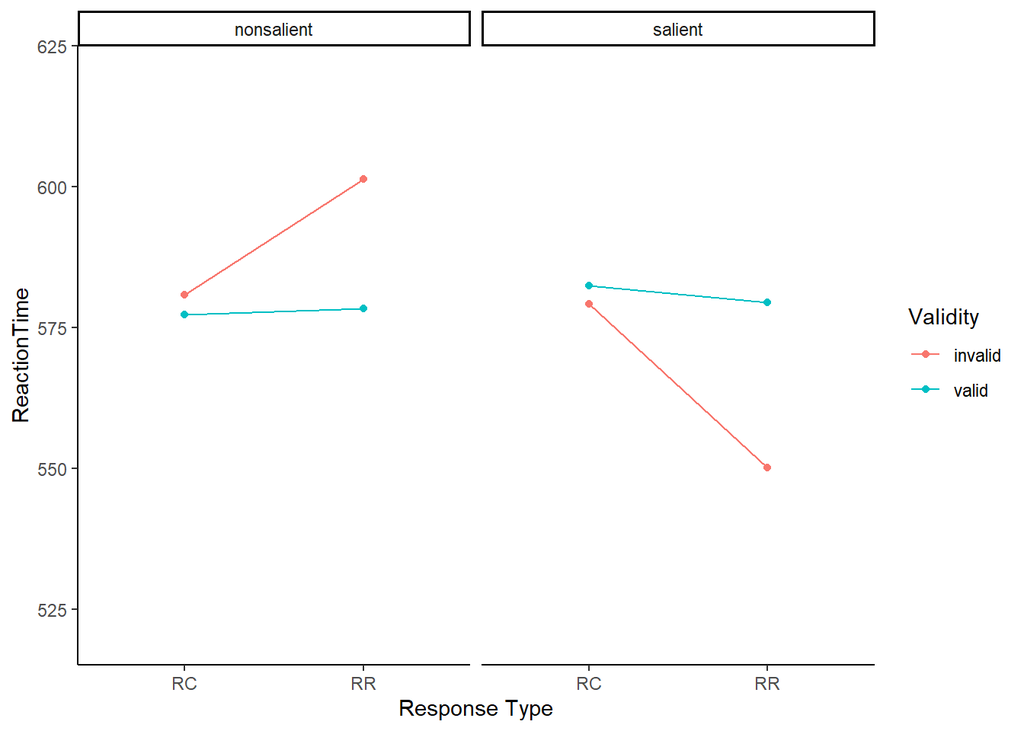

#### Outliers

```r
model_Resp_o <- lmer(RT_io~Sal*Val*RespType + (1|participant), data = Exp1agg_Resp_o)

#summary(model_Resp_o)

anova_Resp_o <- Anova(model_Resp_o, test.statistic = "F", type = "3")

pander(anova_Resp_o,style="rmarkdown",caption = "ANOVA Results of RT(Outliers) x Validity, Saliency and responseType")
```

ANOVA Results of RT(Outliers) x Validity, Saliency and responseType

|  | F | Df | Df.res | Pr(>F) |
| --- | --- | --- | --- | --- |
| **(Intercept)** | 3503 | 1 | 93.57 | 6.028e-76 |
| **Sal** | 0.001029 | 1 | 384 | 0.9744 |
| **Val** | 0.000258 | 1 | 384 | 0.9872 |
| **RespType** | 5.82 | 1 | 384.8 | 0.01631 |
| **Sal:Val** | 0.3348 | 1 | 384 | 0.5632 |
| **Sal:RespType** | 12.42 | 1 | 384.8 | 0.000477 |
| **Val:RespType** | 4.297 | 1 | 384.4 | 0.03884 |
| **Sal:Val:RespType** | 4.764 | 1 | 384.4 | 0.02967 |

#### Plot with ResponseTypeXSaliencyXValidity for Outliers

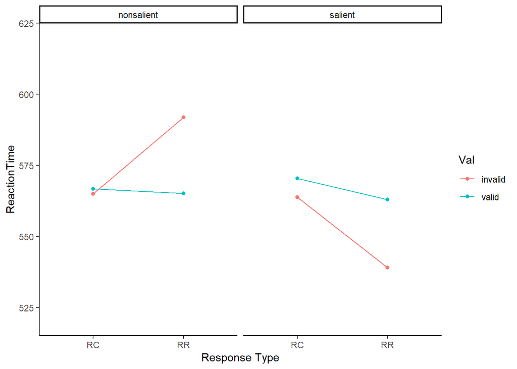

### 2. ANOVA with RT and the factors of Validity, Saliency, ResponseType and Distance

#### Farouts

```r
model_DistRep <- lmer(RT_ifo~Sal*Val*RespType*Dist + (1|participant), data = Exp1agg_fo)
```

```
## fixed-effect model matrix is rank deficient so dropping 14 columns / coefficients
```

```r
anova_DistResp <- Anova(model_DistRep, test.statistic = "F", type = "3")

pander(anova_DistResp,style="rmarkdown",caption = "ANOVA Results of RT x Validity, Saliency,Distance and responseType")
```

ANOVA Results of RT x Validity, Saliency,Distance and responseType

|  | F | Df | Df.res | Pr(>F) |
| --- | --- | --- | --- | --- |
| **(Intercept)** | 1953 | 1 | 248.9 | 7.966e-120 |
| **Sal** | 0.3201 | 1 | 2482 | 0.5716 |
| **Val** | 0.1402 | 1 | 2482 | 0.7081 |
| **RespType** | 2.3 | 1 | 2484 | 0.1295 |
| **Dist** | 2.142 | 13 | 2483 | 0.009817 |
| **Sal:Val** | 0.105 | 1 | 2482 | 0.7459 |
| **Sal:RespType** | 0.7285 | 1 | 2484 | 0.3935 |
| **Val:RespType** | 4.472 | 1 | 2483 | 0.03455 |
| **Sal:Dist** | 2.55 | 12 | 2483 | 0.002368 |
| **Val:Dist** | 0.5005 | 12 | 2483 | 0.9155 |
| **RespType:Dist** | 3.58 | 11 | 2484 | 5.005e-05 |
| **Sal:Val:RespType** | 1.411 | 1 | 2484 | 0.235 |
| **Sal:Val:Dist** | 0.4205 | 11 | 2483 | 0.9478 |
| **Sal:RespType:Dist** | 2.721 | 11 | 2485 | 0.001698 |
| **Val:RespType:Dist** | 2.188 | 10 | 2484 | 0.01605 |
| **Sal:Val:RespType:Dist** | 1.149 | 10 | 2484 | 0.3213 |

#### outliers

```r
model_DistRep_o <- lmer(RT_io~Sal*Val*RespType*Dist + (1|participant), data = Exp1agg_o)
```

```
## fixed-effect model matrix is rank deficient so dropping 15 columns / coefficients
```

```r
anova_DistResp_o <- Anova(model_DistRep_o, test.statistic = "F", type = "3")

pander(anova_DistResp_o,style="rmarkdown",caption = "ANOVA Results of RT(OUtliers) x Validity, Saliency,Distance and responseType")
```

ANOVA Results of RT(OUtliers) x Validity, Saliency,Distance and responseType

|  | F | Df | Df.res | Pr(>F) |
| --- | --- | --- | --- | --- |
| **(Intercept)** | 2356 | 1 | 197.6 | 8.919e-112 |
| **Sal** | 0.1465 | 1 | 2454 | 0.7019 |
| **Val** | 0.2514 | 1 | 2454 | 0.6161 |
| **RespType** | 6.226 | 1 | 2455 | 0.01265 |
| **Dist** | 1.132 | 13 | 2455 | 0.3265 |
| **Sal:Val** | 0.138 | 1 | 2454 | 0.7103 |
| **Sal:RespType** | 1.602 | 1 | 2456 | 0.2057 |
| **Val:RespType** | 6.62 | 1 | 2455 | 0.01014 |
| **Sal:Dist** | 1.718 | 12 | 2455 | 0.05696 |
| **Val:Dist** | 0.7037 | 12 | 2455 | 0.7493 |
| **RespType:Dist** | 2.486 | 11 | 2456 | 0.004222 |
| **Sal:Val:RespType** | 1.062 | 1 | 2455 | 0.3028 |
| **Sal:Val:Dist** | 0.6224 | 11 | 2455 | 0.8112 |
| **Sal:RespType:Dist** | 2.775 | 10 | 2456 | 0.002064 |
| **Val:RespType:Dist** | 1.967 | 10 | 2456 | 0.03302 |
| **Sal:Val:RespType:Dist** | 1.409 | 10 | 2456 | 0.1698 |

```r
#aggDistRespSV_o<- ddply(Exp1agg_o, .(Validity,Saliency,ResponseType,Distance), summarize, RTmean = mean(RT_io))
```

### 3. ANOVA with RT and the factors of Validity, Saliency, ResponseType and LastOccurence Condition

#### Farouts

```r
model_RespLC <- lmer(RT_ifo~Sal*Val*RespType*LastOccCond + (1|participant), data = Exp1agg_RespLC_fo)

# Anova(model_RespLC)
pander(Anova(model_RespLC, test.statistic = "F", type = "3"),style="rmarkdown",caption = "ANOVA Results of RT x Validity, Saliency,LastOccurence condition and responseType")
```

ANOVA Results of RT x Validity, Saliency,LastOccurence condition and responseType #### Plot showing the interaction between the four factors

|  | F | Df | Df.res | Pr(>F) |
| --- | --- | --- | --- | --- |
| **(Intercept)** | 2677 | 1 | 128 | 1.177e-87 |
| **Sal** | 0.05288 | 1 | 668 | 0.8182 |
| **Val** | 0.00774 | 1 | 670.5 | 0.9299 |
| **RespType** | 0.0361 | 1 | 671.8 | 0.8494 |
| **LastOccCond** | 0.02897 | 1 | 668 | 0.8649 |
| **Sal:Val** | 1.697 | 1 | 670 | 0.1931 |
| **Sal:RespType** | 6.308 | 1 | 671.9 | 0.01225 |
| **Val:RespType** | 0.0181 | 1 | 672.4 | 0.893 |
| **Sal:LastOccCond** | 0.0957 | 1 | 668 | 0.7571 |
| **Val:LastOccCond** | 3.452e-06 | 1 | 669.8 | 0.9985 |
| **RespType:LastOccCond** | 1.259 | 1 | 671.6 | 0.2622 |
| **Sal:Val:RespType** | 7.411 | 1 | 672.1 | 0.006652 |
| **Sal:Val:LastOccCond** | 1.012 | 1 | 669.3 | 0.3148 |
| **Sal:RespType:LastOccCond** | 15.46 | 1 | 671.7 | 9.308e-05 |
| **Val:RespType:LastOccCond** | 0.9345 | 1 | 671.9 | 0.334 |
| **Sal:Val:RespType:LastOccCond** | 13.84 | 1 | 671.6 | 0.0002153 |

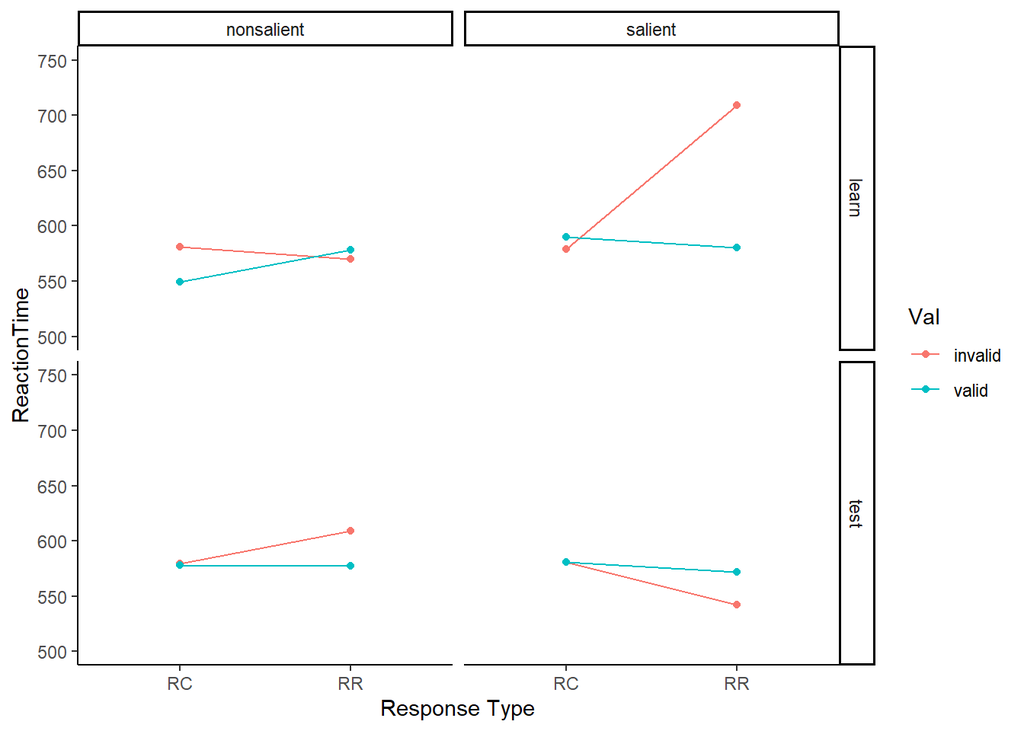

#### outliers

```r
model_RespLC_o <- lmer(RT_io~Sal*Val*RespType*LastOccCond + (1|participant), data = Exp1agg_RespLC_o)

#Anova(model_RespLC_o, test.statistic = "F", type = "3")

pander(Anova(model_RespLC_o, test.statistic = "F", type = "3"),style="rmarkdown",caption = "ANOVA Results of RT x Validity, Saliency,LastOccurence condition and responseType")
```

ANOVA Results of RT x Validity, Saliency,LastOccurence condition and responseType

|  | F | Df | Df.res | Pr(>F) |
| --- | --- | --- | --- | --- |
| **(Intercept)** | 2943 | 1 | 116.1 | 2.401e-84 |
| **Sal** | 0.001176 | 1 | 666 | 0.9727 |
| **Val** | 0.8359 | 1 | 668.2 | 0.3609 |
| **RespType** | 0.2846 | 1 | 669.2 | 0.5939 |
| **LastOccCond** | 0.03614 | 1 | 666 | 0.8493 |
| **Sal:Val** | 1.224 | 1 | 667.7 | 0.2691 |
| **Sal:RespType** | 6.299 | 1 | 669.3 | 0.01232 |
| **Val:RespType** | 0.9238 | 1 | 669.8 | 0.3368 |
| **Sal:LastOccCond** | 0.03546 | 1 | 666 | 0.8507 |
| **Val:LastOccCond** | 0.4161 | 1 | 667.5 | 0.5191 |
| **RespType:LastOccCond** | 0.1179 | 1 | 669 | 0.7315 |
| **Sal:Val:RespType** | 7.421 | 1 | 669.4 | 0.006615 |
| **Sal:Val:LastOccCond** | 0.6469 | 1 | 667.1 | 0.4215 |
| **Sal:RespType:LastOccCond** | 13.38 | 1 | 669.1 | 0.0002748 |
| **Val:RespType:LastOccCond** | 0.005492 | 1 | 669.3 | 0.9409 |
| **Sal:Val:RespType:LastOccCond** | 12.87 | 1 | 669 | 0.0003585 |

#### Plot showing the interaction

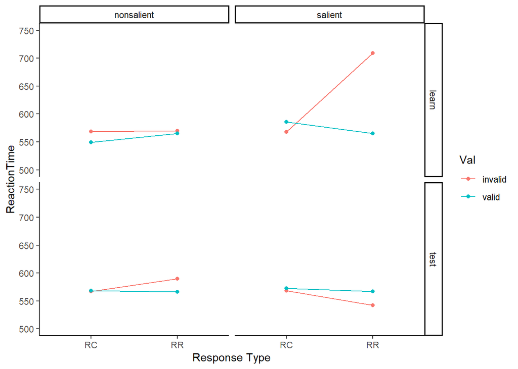